# Ford GoBike System Data

## by Hatem Yehia

## Investigation Overview

> In this presentation I will try to show how the distribution of the rides varies with time of the day and week day.

## Dataset Overview

> This data set includes information about individual rides made in a bike-sharing system covering the greater San Francisco Bay area. The data is collected in Febuary 2019.

## (Visualization 1)

> The trip duration is found to have a gamma distribution, which is logical with time random variables. When log transformed, it shows an almost noraml distribution with median of 8.6 minutes.

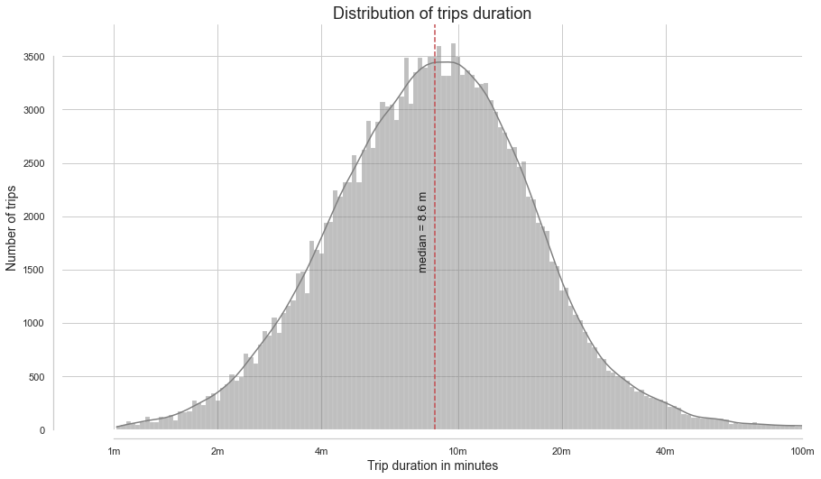

## (Visualization 2)

> There is an interesting pattern found about the trips occurance, which peaks at 8 AM and again at 5 PM as shown here.

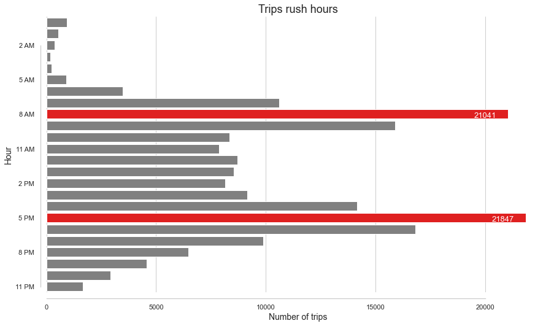

## (Visualization 3)

> There is a noticable drop in trips during weekends compared to weekdays as showen here:

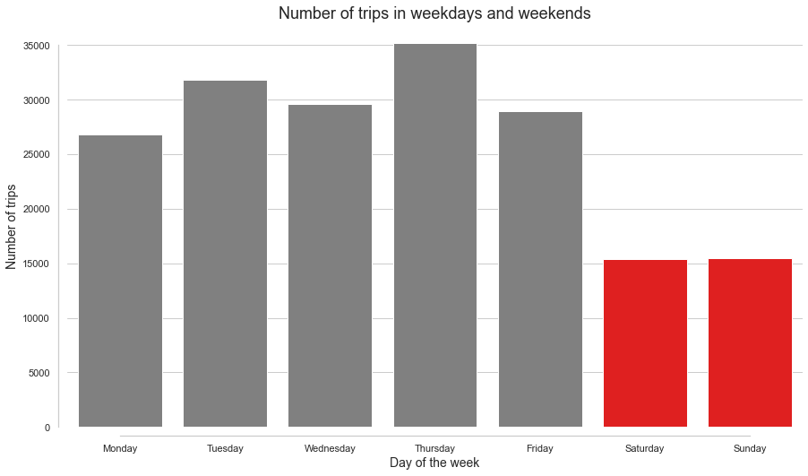

## (Visualization 4)

> There is a trend that trips on weekends tend to be longer than weekdays, although they are less as shown before. During the day, the longest trips happen between 11 AM and 4 PM.

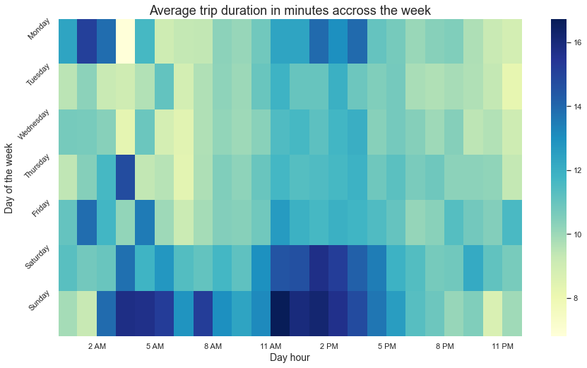

## (Visualization 5)

> We can see that females on average has longer trips than males. We find a major drop in trip duration for users above 70, which is much expected.

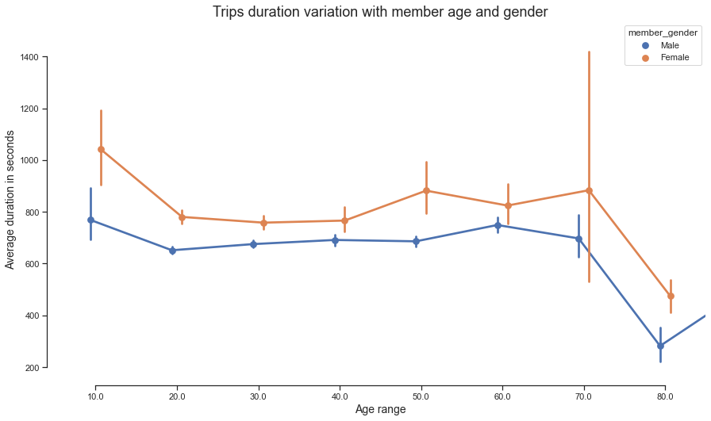

## (Visualization 6)

> We can notice that subscribers tend to have shorter trips compared to customers in general. In addition, there are no customers that use bike share for all trips. Between subscribers, those who use bike share for all trips have slightly shorter trips.

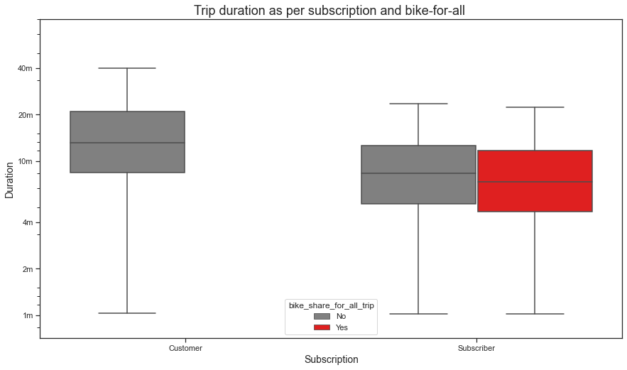